# scRNA-seq analysis of RRMM tumor cells

```r
library(dplyr)
library(tidyverse)
library(Seurat)
library(ggplot2)
library(sctransform)
library(qs)
library(RhpcBLASctl)
library(ggpointdensity)
library(viridis)
library(patchwork)
library(data.table)
library(presto)
library(RColorBrewer)
library(ComplexHeatmap)
library(circlize)
library(phylogram)
library(dendextend)
```

## For InferCNV code (Sup_Fig.2) -> see Nextflow pipeline

### for reduced UMAP visualization

```r
blank <- theme(axis.line=element_blank(),axis.text.x=element_blank(),
          axis.text.y=element_blank(),axis.ticks=element_blank(),
          axis.title.x=element_blank(),
          axis.title.y=element_blank(),legend.position="none",
          panel.background=element_blank(),panel.border=element_blank(),panel.grid.major=element_blank(),
          panel.grid.minor=element_blank(),plot.background=element_blank())
```

### Load complete RRMM dataset (all patients, all time-points, BME + PCs) + metadata

```r
K43R_all <- qread(".../K43R_all.qs")
```

### Filter PCs

```r
Idents(K43R_all) <- "major_population"
PCs <- subset(K43R_all, idents = "PCs")
```

```r
blas_set_num_threads(1)
omp_set_num_threads(1)
options(future.globals.maxSize=50*1024^3)
PCs <- SCTransform(PCs, vars.to.regress = c("percent.mt", "G2M.Score", "S.Score", "nFeature_RNA"), verbose = F)
```

### PCA

```r
PCs <- RunPCA(object = PCs, npcs = 100, verbose = FALSE)
ElbowPlot(object = PCs, ndims = 100)
```

```r
PCs <- FindNeighbors(object = PCs, reduction = "pca", dims = 1:100)
PCs <- FindClusters(PCs, resolution = 0.3, verbose = F)
PCs <- RunUMAP(object = PCs, reduction = "pca", dims = 1:100, verbose = F)
```

UMAP colored by subject

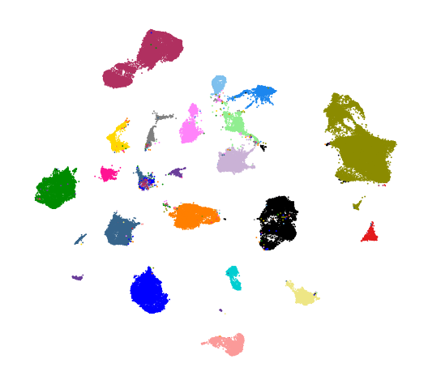

```r
p1 <- DimPlot(object = PCs, reduction = 'umap', pt.size = 0.0001,
              group.by = "PID_new") +
  scale_color_manual(values=c(
  "dodgerblue2",
  "#E31A1C", # red
  "green4",
  "#6A3D9A", # purple
  "maroon",
  "#FF7F00",
  "gold1",
  "skyblue2",
  "#FB9A99", # lt pink
  "palegreen2",
  "#CAB2D6", # lt purple
  "yellow4", # lt orange
  "gray50",
  "khaki2",
  "black", # orange,
  "orchid1",
  "deeppink1",
  "blue1",
  "steelblue4",
  "darkturquoise",
  "yellow4",
  "yellow3"
  ))+
  theme(legend.position = "none") + blank
p1
```

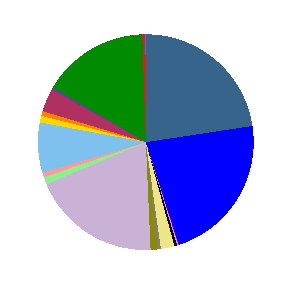

```r
df <- as.data.frame(table(PCs$PID_new[PCs$celltype_1=="PC"]))
df <- df[order(df$Freq),]
bp<- ggplot(df, aes(x="", y=Freq, fill=Var1))+
geom_bar(width = 1, stat = "identity")+
  scale_fill_manual(values=c(
  "dodgerblue2",
  "#E31A1C", # red
  "green4",
  "#6A3D9A", # purple
  "maroon",
  "#FF7F00",
  "gold1",
  "skyblue2",
  "#FB9A99", # lt pink
  "palegreen2",
  "#CAB2D6", # lt purple
  "yellow4", # lt orange
  "gray50",
  "khaki2",
  "black", # orange,
  "orchid1",
  "deeppink1",
  "blue1",
  "steelblue4",
  "darkturquoise",
  "yellow4",
  "yellow3"
  ))
pie <- bp + coord_polar("y", start=0)
pie1 <- pie +
  theme(legend.position = "none") +
  blank
pie1
```

#### fraction of nPCs per patient

```r
df <- as.data.frame(table(PCs$PID_new[PCs$celltype_1=="PC"]))
df <- rbind(df,RRMM20 = 0)
```

```
invalid factor level, NA generated
```

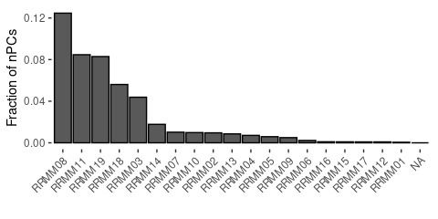

```r
df2 <- as.data.frame(table(PCs$PID_new))
df3 <- cbind(df, df2$Freq)
df3$prop <- with(df3, Freq / df2$Freq)

p1 <- ggplot(df3, aes(y=prop, x=reorder(Var1, -prop))) +
    geom_bar(position="dodge", stat="identity", color="black") +
 theme(axis.text.x = element_text(angle = 45, hjust = 1), panel.background=element_blank()) +
  xlab("") + ylab("Fraction of nPCs")
p1
```

### Subset myeloma cells only (remove nPCs)

```r
Idents(PCs) <- "celltype_1"
Myeloma <- subset(PCs, idents= "PC", invert = T)
```

### Matrices tumor cells

##1) based on cytogenetics

```r
## Annotation
df_ann <- FetchData(Myeloma, vars = c("pid_id","hyperdiploidy"))
df_ann_sum <- df_ann %>%
  group_by(pid_id)  %>% summarise_all(funs(toString(unique(.[!is.na(.)]))))
```

[output not shown]

```r
df_ann_sum <- df_ann_sum[-c(4,19, 20,22, 24, 25,33),] # remove patients with no cytogenetic information

ha <- rowAnnotation(Hyperdyploid = df_ann_sum$hyperdiploidy,
                    col = list(Hyperdyploid = c("F" = "grey90", "T"="maroon")))


## Cytogenetic heatmap
df <- FetchData(Myeloma, vars = c("pid_id","t11.14", "t4.14", "t14.16",
                                  "gain_1q21", "gain_5p15", "gain_5q13", "gain_5q35", "gain_6p21", "gain_8q24",
                                  "gain_9q34", "gain_11q13", "gain_11q22.3", "gain_15q22", "gain_19q13",
                                  "del_8p21", "del_11q22", "del_13q14", "del_14q32", "del_16q23", "del_17p13",
                                  "re_MYC", "re_IGH"))

df_sum <- df %>%
  group_by(pid_id)  %>% summarise_all(funs(toString(unique(.[!is.na(.)]))))

df_sum <- df_sum[-c(4,19, 20,22, 24, 25,33),] # remove samples with no cytogenetic information

df_sum <- tibble::column_to_rownames(df_sum, "pid_id")
#df_sum <- t(df_sum)
require(ComplexHeatmap)
dist_letters = function(x, y) {
    x = strtoi(charToRaw(paste(x, collapse = "")), base = 16)
    y = strtoi(charToRaw(paste(y, collapse = "")), base = 16)
    sqrt(sum((x - y)^2))
}
#colors = structure(1:2, names = c("1", "0"))
colors = c("white", "black")
hm1 <- Heatmap(df_sum, clustering_distance_rows = dist_letters,
              clustering_distance_columns = dist_letters,
              col = colors,
              rect_gp = gpar(col = "grey", lwd = 1),
              right_annotation = ha)
```

```
The input is a data frame, convert it to the matrix.
```

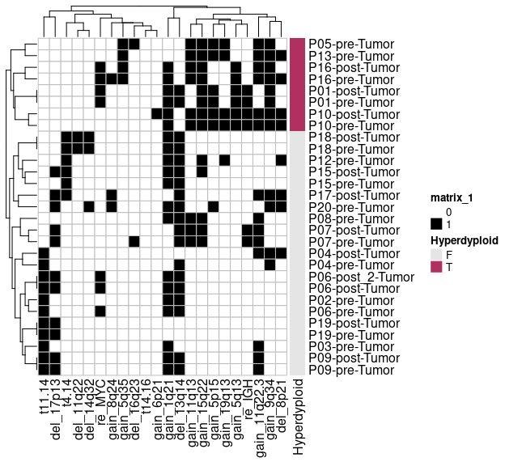

```r
hm1
```

### Using averaged expression

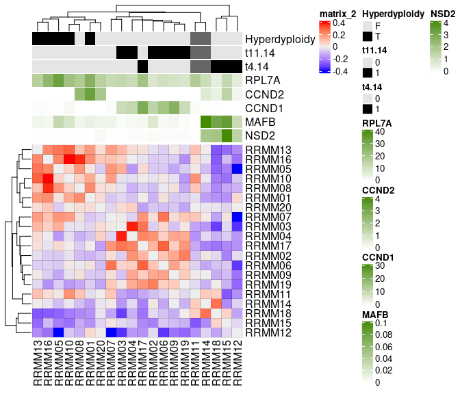

```r
### calculate average expression correlations
Idents(Myeloma) <- "PID_new"
av.exp <- AverageExpression(Myeloma, assays = "SCT", slot = "scale.data", verbose = F)$SCT
cor.exp <- as.matrix(cor(av.exp, method = "pearson"))
diag(cor.exp) = 0

# get average gene expression of drivers
av.exp_obj <- AverageExpression(Myeloma, assays = "SCT", slot = "data", verbose = F, return.seurat = T)
matrix <- GetAssayData(object = av.exp_obj, slot = "counts")
df <- as.data.frame(matrix)
df <- t(df)
df <- as.data.frame(df)
df <- df %>% select(CCND1, MYC, NSD2, RPL7A, MYC, MAFB, CCND2)
df <- tibble::rownames_to_column(df, "PID_new")


# get metadata info
df_ann <- FetchData(Myeloma, vars = c("PID_new","hyperdiploidy", "t4.14", "t11.14", "del_17p13"))
df_ann_sum <- df_ann %>%
  group_by(PID_new)  %>% summarise_all(funs(toString(unique(.[!is.na(.)]))))

df_ann_sum[df_ann_sum=="0, 1"] <- "1" # change heterogeneously detected to detected
df_ann_sum[df_ann_sum=="1, 0"] <- "1"
df_ann_sum[df_ann_sum==""] <- NA

df_ann_sum <- df_ann_sum[ order(match(df_ann_sum$PID_new, df$PID_new)), ]
df_final <- cbind(df, df_ann_sum)

#specify colors and breaks for average gene expression values
col_fun1 = colorRamp2(c(0, 40), c("white", "chartreuse4"))

col_fun3 = colorRamp2(c(0, 4), c("white", "chartreuse4"))
col_fun4 = colorRamp2(c(0, 30), c("white", "chartreuse4"))
col_fun5 = colorRamp2(c(0, 0.1), c("white", "chartreuse4"))
col_fun6 = colorRamp2(c(0, 4), c("white", "chartreuse4"))

ha <- HeatmapAnnotation(Hyperdyploidy = df_final$hyperdiploidy,
                        t11.14 = df_final$t11.14,
                        t4.14 = df_final$t4.14,
                        RPL7A = df_final$RPL7A,
                        CCND2 = df_final$CCND2,
                        CCND1 = df_final$CCND1,
                        MAFB = df_final$MAFB,
                        NSD2 = df_final$NSD2,
                        col = list(Hyperdyploidy = c("F" = "grey90", "T"="black"),
                                   t11.14 = c("0" = "grey90", "1" = "black"),
                                   t4.14 = c("0" = "grey90", "1" = "black"),
                                   RPL7A = col_fun1,
                                   CCND2 = col_fun3,
                                   CCND1 = col_fun4,
                                   MAFB  = col_fun5,
                                   NSD2  = col_fun6),
                        na_col = "grey40")



ComplexHeatmap::Heatmap(cor.exp, rect_gp = gpar(col = "black", lwd = 0.1), top_annotation = ha)
```

### Correlation FISH - InferCNV percentages

```r
library(ggpubr)

# load percentages of 1q cells from FISH and InferCNV (see supp. file 1)
df <- read.csv("/Volumes/ag-rippe/NGS_Stephan/HIPO2_K43R/Analysis_v3/_Metadata_info/CNVs/FISH_InferCNV_percentages.csv", sep = ";", header = T, dec = ",")

# remove rows with NA
df <- df[-c(5, 19, 20, 23, 24, 25,35), ]

df$FISH_1q21_perc <- as.numeric(as.character(df$FISH_1q21_perc))
df$InferCNV_1q_perc <- as.numeric(as.character(df$InferCNV_1q_perc))


 require(ggpubr)
p1 <- ggplot(df, aes(x=FISH_1q21_perc, y=InferCNV_1q_perc)) +
  geom_point(colour="black", size=5, alpha = 0.3) +
  theme(legend.position = "none")+
  theme(panel.background=element_blank(),
        axis.line = element_line(size = .5, colour = "black")) +
  xlab("Fraction of cells with 1q21 gain (iFISH)") +
  ylab("Fraction of cells with 1q gain (InferCNV)")
  geom_text()
```

```
geom_text: parse = FALSE, check_overlap = FALSE, na.rm = FALSE
stat_identity: na.rm = FALSE
position_identity
```

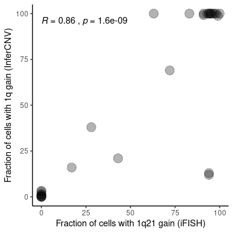

```r
 p1 <- p1 + stat_cor(method = "pearson")
p1
```

```r
NA
NA
```

### Cluster-clone & cell number relationship

```r
df <- read_excel("/Volumes/ag-rippe/NGS_Stephan/HIPO2_K43R/Analysis_v3/_Metadata_info/CNVs/K43R_summary_cluster_clones.xlsx")

p1 <- ggplot(df, aes(x=cell_number, y=clusters)) +
  geom_point(size=2.5) +
  scale_x_continuous(trans='log10') +
  theme(panel.background=element_blank(), axis.line = element_line(size = 0.5, colour = "black")) +
  scale_color_manual(values=c("#999999", "#E69F00", "#56B4E9"))  +
  theme(legend.position = "none") + stat_cor(method = "pearson") + stat_cor(method = "pearson") +
  geom_smooth(method=lm, color="black", size= 0.5)


p2 <- ggplot(df, aes(x=clusters, y=clones)) +
  geom_point(aes(size=cell_number))  +
  theme(panel.background=element_blank(), axis.line = element_line(size = 0.5, colour = "black")) +
  scale_color_manual(values=c("#999999", "#E69F00", "#56B4E9")) + stat_cor(method = "pearson") +
  geom_smooth(method=lm, color="black", size= 0.5) +
  ylim(0,14)


df_2 <- df %>%
    group_by(deviation_group) %>%
    count()

df_2$deviation_group <- factor(df_2$deviation_group,   # Change ordering manually
                  levels = c("0–2", "3-4", ">4"))

p3 <- ggplot(data=df_2, aes(x=deviation_group, y= n)) +
  geom_bar(stat="identity", width=0.5) +
 theme(axis.text.x = element_text(angle = 90, hjust = 1)) +
  xlab("cluster-clone # deviation") + ylab("Number of patients") +
  theme_minimal()


p4 <- p1 | p2 | p3
p4
```

## 1q-gain signature

### Perform DEA between clone with 1q-gain vs. most similar clone without 1q gain for all patients with subclonal 1q-gain

e.g. for RRMM05 (ID=“6KLSUS”):

```r
Idents(Myeloma) <- "patient"
Tumor_6KLSUS <- subset(Myeloma, idents= "6KLSUS")

DEA <- wilcoxauc(Tumor_6KLSUS, group_by = "tumor_clone",groups_use = c("6KLSUS_clone_2","6KLSUS_clone_3"), seurat_assay = "SCT", assay = "data")
DEA <- DEA %>% filter(group=="6KLSUS_clone_2")
DEA <- DEA %>% filter(padj < 0.05)
DEA_clone_6KLSUS <- DEA %>% filter(logFC > 0.1)
```

other comparisons: - RRMM03: cl.2 vs. cl.3 - RRMM07: cl.2 vs. cl.3 - RRMM08: cl.1 vs. cl.2 - RRMM09: cl.2 vs. cl.1 - RRMM10: cl.2 vs. cl.1 - RRMM11: cl.2 vs. cl.3 - RRMM13: cl.2 vs. cl.3 - RRMM16: cl.4 vs. cl.5 - RRMM19: cl.1 vs. cl.2

```r
## load all DEA gene lists and compute overlap
require(ComplexHeatmap)
m = make_comb_mat(list_1q)
comb_name(m)
```

### Load annotated 1q-up signature gene list (see sup. file 2)

```r
df_1q <- read.table(sep = ";",header = T,
                    "/media/ag-rippe/NGS_Stephan/HIPO2_K43R/Analysis_v3/_Metadata_info/CNVs/Signature_1q_up.csv")
df_1q <- df_1q[1:66,]

#only genes located on 1q
df_1q <-  df_1q %>% filter(location_1q == TRUE)
```

###Plot signature with annotations and intersect ratio

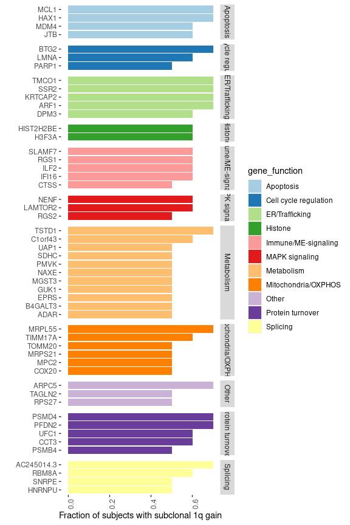

```r
p1 <- ggplot(df_1q, aes(y=intersect_fraction, x=reorder(gene, intersect_fraction), fill = gene_function)) +
    geom_bar(position="dodge", stat="identity") +
    facet_grid(gene_function ~., scales = "free", space = "free") +
    theme(axis.text.x = element_text(angle = 90, hjust = 0), panel.background=element_blank()) +
    xlab("") + ylab("Fraction of subjects with subclonal 1q gain") + coord_flip() +scale_fill_brewer(palette="Paired")
p1
```

Add 1q signature score

```r
df_1q <- df_1q[1]
genes_1q_up <- as.character(df_1q$gene)
genes_1q_up <- list(c(genes_1q_up))
Myeloma <- AddModuleScore(Myeloma, features = genes_1q_up, name = "Up_1q_score", assay = "SCT")
```

## Generate plot: Average signature score vs fraction of cells with 1q-gain with both patient and sample information

#### First patient-wise

```r
df <- FetchData(Myeloma, vars = c("patient","sc_gain_1q"))
df <- df %>% modify_if(is.character, as.factor)

df_freq <- df %>%
  group_by(patient) %>%
  dplyr::count(sc_gain_1q, .drop = T) %>%
  mutate(prop=prop.table(n)) %>%
  mutate(prop=format(prop,digits=2))
df_freq$prop <- as.numeric(as.character(df_freq$prop))


df_freq <- df_freq %>% filter(sc_gain_1q=="T")
df_freq <- df_freq[, c(1,4)]

## Add samples with 0 cells with 1q gain again
patient <- c("6K8YTY", "R1V8RN","XF2DTB")
prop <- c(0, 0, 0)
data <- data.frame(patient, prop)


data_combi <- bind_rows(df_freq, data)


### Avg. signature expression taken from ggplot (Dotplot) Object
p1 <- DotPlot(Myeloma, dot.scale = 7,
         features = c("Up_1q_score1"), group.by = "patient") +
  RotatedAxis()+
  scale_color_gradient( low="blue",high="red") +
  theme(axis.text.x = element_text(size=10))+
  theme(axis.text.y = element_text(size=12))

df_2 <- p1$data
df_2 <- p1$data
df_2 <- df_2[,c(4,5)]
rownames(df_2) <- NULL
colnames(df_2) <- c("patient", "avg_score")

data_all <- merge(data_combi, df_2, by= "patient")


## Add cytogenetic information for 1q21 gain
df <- FetchData(Myeloma, vars = c("patient","gain_1q21"))
df <- df %>% modify_if(is.character, as.factor)

df_freq <- df %>%
  group_by(patient) %>%
  dplyr::count(gain_1q21, .drop = T)
df_freq <- df_freq[1:36,]

data_all <- merge(data_all, df_freq, by="patient")

data_all$gain_1q21 <- as.character(data_all$gain_1q21)
data_all$gain_1q21[is.na(data_all$gain_1q21)] <- "NA"

data_all_patient <- data_all
data_all_patient$gain_1q21 <- "patient"
colnames(data_all_patient) <- c("pid_id", "prop", "avg_score", "gain_1q21", "n")
```

### Sample wise

```r
df <- FetchData(Myeloma, vars = c("pid_id","sc_gain_1q"))
df <- df %>% modify_if(is.character, as.factor)

df_freq <- df %>%
  group_by(pid_id) %>%
  dplyr::count(sc_gain_1q, .drop = T) %>%
  mutate(prop=prop.table(n)) %>%
  mutate(prop=format(prop,digits=2))
df_freq$prop <- as.numeric(as.character(df_freq$prop))


df_freq <- df_freq %>% filter(sc_gain_1q=="T")
df_freq <- df_freq[, c(1,4)]

## Add samples with 0 cells with 1q gain again
pid_id <- c("P04-pre-Tumor","P04-post-Tumor", "P14-pre-Tumor","P14-post-Tumor", "P17-post-Tumor")
prop <- c(0, 0, 0, 0, 0)
data <- data.frame(pid_id, prop)


data_combi <- bind_rows(df_freq, data)


### Avg. signature expression taken from ggplot (Dotplot) Object
p1 <- DotPlot(Myeloma, dot.scale = 7,
         features = c("Up_1q_score1"), group.by = "pid_id") +
  RotatedAxis()+
  scale_color_gradient( low="blue",high="red") +
  theme(axis.text.x = element_text(size=10))+
  theme(axis.text.y = element_text(size=12))
p1

df_2 <- p1$data
df_2 <- p1$data
df_2 <- df_2[,c(4,5)]
rownames(df_2) <- NULL
colnames(df_2) <- c("pid_id", "avg_score")

data_all <- merge(data_combi, df_2, by= "pid_id")


### Add cytogenetic information for 1q21 gain
df <- FetchData(Myeloma, vars = c("pid_id","gain_1q21"))
df <- df %>% modify_if(is.character, as.factor)

df_freq <- df %>%
  group_by(pid_id) %>%
  dplyr::count(gain_1q21, .drop = T)
df_freq <- df_freq[1:36,]

data_all <- merge(data_all, df_freq, by="pid_id")

data_all$gain_1q21 <- as.character(data_all$gain_1q21)
data_all$gain_1q21[is.na(data_all$gain_1q21)] <- "NA"

data_all_sample <- data_all
```

## Plot both together

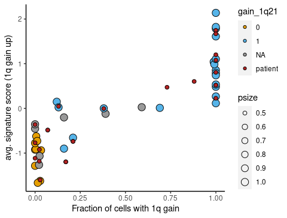

```r
data_all <- rbind(data_all_sample, data_all_patient)

require(ggpubr)
p1 <-
  data_all %>% mutate(psize=ifelse(gain_1q21=="patient",0.5,1)) %>%
  ggplot(aes(x=prop, y=avg_score,size=psize)) +
  geom_point(aes(fill=gain_1q21),
       colour="black",pch=21) +
  scale_size(range = c(2,4)) +
  theme(panel.background=element_blank(),
        axis.line = element_line(size = .5, colour = "black")) +
  xlab("Fraction of cells with 1q gain") +
  ylab("avg. signature score (1q gain up)") +
  scale_fill_manual(values=c("#E69F00", "#56B4E9","#999999", "firebrick"))
p1
```

### PLot 1q score for groups as Violinplot

```r
Idents(Myeloma) <- "sc_gain_1q_classification"
levels(Myeloma) <- c("sc_1q-low", "sc_1q-int","sc_1q-high")

df <- as.data.frame(Myeloma@active.ident)
Myeloma <- AddMetaData(Myeloma, col.name = "sc_gain_1q_classification", metadata = df)
```

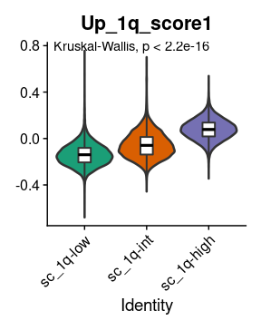

```r
p3 <- VlnPlot(Myeloma, features = "Up_1q_score1", group.by = "sc_gain_1q_classification", pt.size = 0,
               slot = "data", assay = "SCT", sort = F) +
  geom_boxplot(width=.2, outlier.colour=NA, fill= "white", lwd=0.7, fatten =0) +
    stat_summary(fun = mean, geom = "errorbar", aes(ymax = ..y.., ymin = ..y..),
               width = 0.2, size = 1, linetype = "solid") +
  theme(legend.position = "none") + stat_compare_means() +scale_fill_brewer(palette="Dark2")
p3$layers[[1]]$aes_params$size = 0.9
p3
```

## Patient RRMM05 only (ID: 6KLSUS)

```r
Idents(K43R_all) <- "patient"
Tumor_6KLSUS <- subset(K43R_all, idents = "6KLSUS")
```

```r
blas_set_num_threads(1)
omp_set_num_threads(1)
options(future.globals.maxSize=50*1024^3)
Tumor_6KLSUS <- SCTransform(Tumor_6KLSUS, vars.to.regress = c("percent.mt", "G2M.Score", "S.Score"),
                            verbose = F, do.scale = F, return.only.var.genes = F)
```

### PCA

```r
Tumor_6KLSUS <- RunPCA(object = Tumor_6KLSUS, npcs = 50, verbose = FALSE)
ElbowPlot(object = Tumor_6KLSUS, ndims = 50)
```

```r
Tumor_6KLSUS <- RunHarmony(Tumor_6KLSUS, group.by.vars = "sorting", assay.use="SCT",   max.iter.harmony = 5, verbose = F)
```

#### Clustering etc.

```r
Tumor_6KLSUS <- FindNeighbors(object = Tumor_6KLSUS, reduction = "harmony", dims = 1:30)
Tumor_6KLSUS <- FindClusters(Tumor_6KLSUS, resolution = .3, verbose = F)
Tumor_6KLSUS <- RunUMAP(object = Tumor_6KLSUS, reduction = "harmony", dims = 1:30, verbose = F)
```

### Add InferCNV info

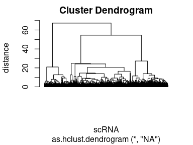

```r
infercnv.observations <- "/Volumes/ag-rippe2/NGS_Simon/HIPO_K43R_nextflow_2/infercnv_out/6KLSUS/InferCNV_out/infercnv.observations_dendrogram.txt"

# get and visualize the dendrogram

dend <- as.hclust(read.dendrogram(infercnv.observations))
plot(dend,labels = FALSE,hang = -1,xlab = "scRNA",ylab = "distance")
```

#### Load CNV heatmap

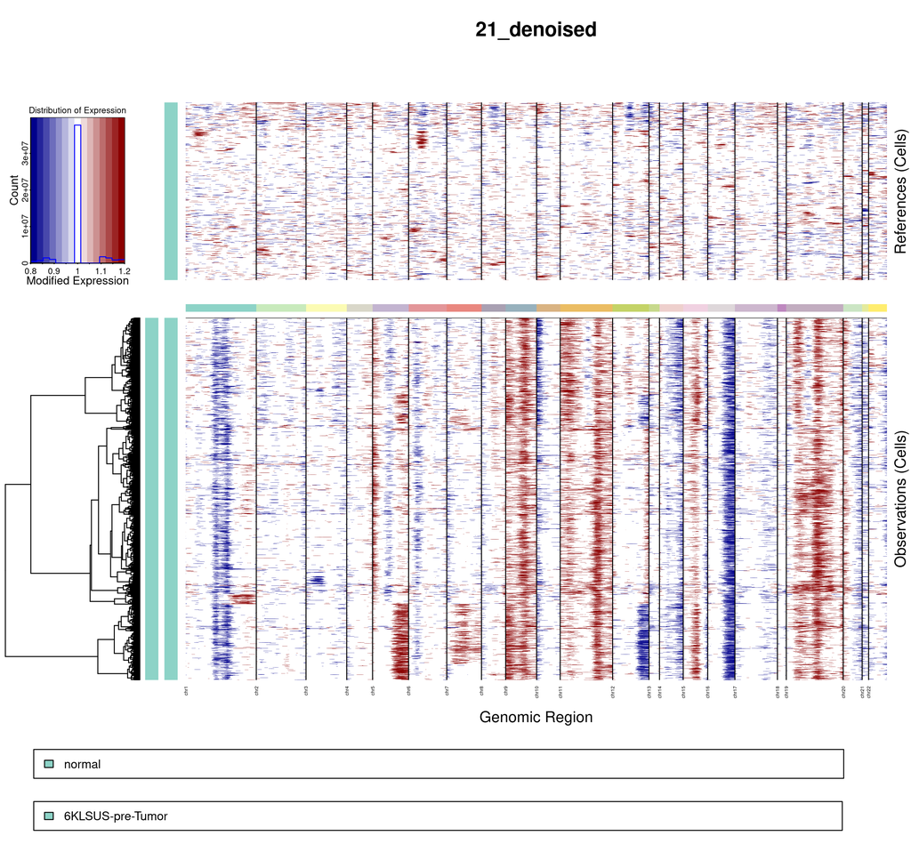

```r
knitr::include_graphics("/Volumes/ag-rippe2/NGS_Simon/HIPO_K43R_nextflow_2/infercnv_out/6KLSUS/InferCNV_out/infercnv.21_denoised.png")
```

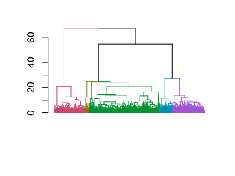

```r
NCLONES <- 5

tp <- color_branches(dend, k = NCLONES)
plot(tp,leaflab = 'none')
```

```r
g <- cutree(dend,k = NCLONES)
groups <- data.frame(BARCODE=names(g),#BARCODE=barcodes,
                     CLONE=as.numeric(g),
                     stringsAsFactors = F)

names <- as.data.frame(colnames(Tumor_6KLSUS))
names(names)[1] <- "Barcode"
names <- as.vector(as.character(names$Barcode))
combi_names_sort <- groups[match(names, groups$BARCODE),]

Tumor_6KLSUS <- AddMetaData(Tumor_6KLSUS, col.name = "tumor_clone", combi_names_sort$CLONE)

Tumor_6KLSUS[["tumor_clone"]] <- ifelse(Tumor_6KLSUS$tumor_clone=="1","6KLSUS_clone_1",as.character(Tumor_6KLSUS$tumor_clone))
Tumor_6KLSUS[["tumor_clone"]] <- ifelse(Tumor_6KLSUS$tumor_clone=="2","6KLSUS_clone_2",as.character(Tumor_6KLSUS$tumor_clone))
Tumor_6KLSUS[["tumor_clone"]] <- ifelse(Tumor_6KLSUS$tumor_clone=="3","6KLSUS_clone_3",as.character(Tumor_6KLSUS$tumor_clone))
Tumor_6KLSUS[["tumor_clone"]] <- ifelse(Tumor_6KLSUS$tumor_clone=="4","6KLSUS_clone_4",as.character(Tumor_6KLSUS$tumor_clone))
Tumor_6KLSUS[["tumor_clone"]] <- ifelse(Tumor_6KLSUS$tumor_clone=="5","6KLSUS_clone_5",as.character(Tumor_6KLSUS$tumor_clone))
```

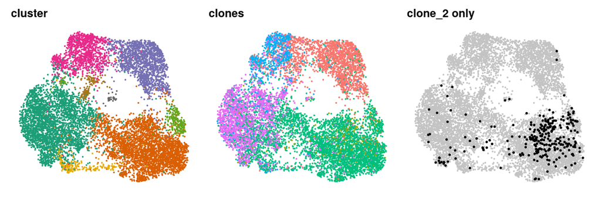

```r
p1 <- DimPlot(object = Tumor_6KLSUS, reduction = 'umap', pt.size = 0.5, label = F, group.by = "tumor_cluster", cols = "Dark2") +
  blank +
  ggtitle("cluster")

p2 <- DimPlot(object = Tumor_6KLSUS, reduction = 'umap', pt.size = 0.5, label = F, group.by = "tumor_clone") +
  blank +
  ggtitle("clones")


cells.use <- names(Tumor_6KLSUS@active.ident[Tumor_6KLSUS@meta.data$tumor_clone=="6KLSUS_clone_2"])
p3 <- DimPlot(object = Tumor_6KLSUS, reduction = 'umap', pt.size = 0.5, label = F,
              cells.highlight = cells.use, sizes.highlight = 1, cols.highlight = "black") +
  blank +
  ggtitle("clone_2 only")

p4 <- p1 | p2 | p3
p4
```

# plot clone fraction

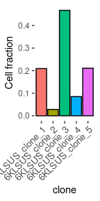

```r
df <- FetchData(Tumor_6KLSUS, vars = c("tumor_clone"))
df <- df %>% modify_if(is.character, as.factor)

df_freq <- df %>%
  group_by(tumor_clone) %>%
  summarise(n = n()) %>%
  mutate(freq = n / sum(n)) %>%
  mutate(freq=format(freq,digits=2))

df_freq$freq <- as.numeric(as.character(df_freq$freq))

p1 <- ggplot(df_freq, aes(y=freq, x=tumor_clone, fill = tumor_clone)) +
    geom_bar(stat="identity", color = "black")  +
  theme(axis.text.x = element_text(angle = 45, hjust = 1, size = 10), panel.background=element_blank()) +
  xlab("clone") + ylab("Cell fraction") +
  theme(legend.position = "none")
p1
```

### Heatmap of upregulated genes

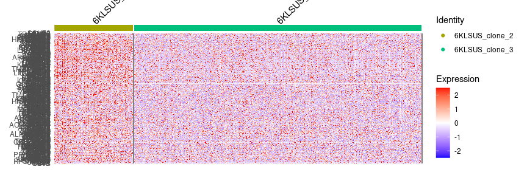

```r
DEA_clone_6KLSUS <- DEA_clone_6KLSUS %>% filter(logFC > 0.1)

Idents(Tumor_6KLSUS) <- "tumor_clone"
cl_2_3 <- subset(Tumor_6KLSUS, idents = c("6KLSUS_clone_2", "6KLSUS_clone_3"), downsample = 1000)

p1 <- DoHeatmap(cl_2_3, features = DEA_clone_6KLSUS$feature, group.by = "tumor_clone",
          group.colors = c("#A3A500", "#00BF7D"), group.bar.height = 0.05, size = 4, raster = F)+
  scale_fill_gradient2( low="blue",high="red", mid = "white")
p1
```

#### Link upregulated DE genes in Clone_2 to chromosomal locations

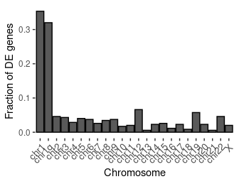

```r
DEA_up <- DEA %>% filter(logFC > 0.1)
DEA_up <- DEA_up[c(1)]
df <- read.table("/media/ag-rippe/NGS_Stephan/General/gene_lists/gencode_v28_CR_ref_gene_pos.txt")  # CellRanger derived position file
df <- df[ -c(3,4) ]

df_2 <- data.frame(feature=DEA_up$feature, chr=df[match(DEA_up$feature, df$V1),2])

df_2$chr <- as.character(df_2$chr)
df_2$chr[is.na(df_2$chr)] <- "X"

df_2 <- df_2 %>% modify_if(is.character, as.factor)

df_count <- plyr::count(df_2, vars = "chr")
df_prop <- df_count %>%
  mutate(prop=prop.table(freq)) %>%
  mutate(prop=format(prop,digits=2))
df_prop$prop <- as.numeric(as.character(df_prop$prop))


#Located on 1p =12 genes
# Add row for 1q location (123-12)/348=0.32

df_add <- data.frame("chr1q", 111,0.32)
names(df_add) <- c("chr", "freq", "prop")
df_prop <- rbind(df_prop, df_add)


p1 <- df_prop %>%
  mutate(chr = fct_relevel(chr,
            "chr1","chr1q", "chr2", "chr3", "chr4", "chr5",
            "chr6", "chr7", "chr8","chr9","chr10", "chr11",
            "chr12","chr13", "chr14", "chr15", "chr16", "chr17","chr18",
            "chr19","chr20", "chr21", "chr22", "X")) %>%
  ggplot( aes(y=prop, x=chr)) +
    geom_bar(color="black",stat="identity")  +
  theme(axis.text.x = element_text(angle = 45, hjust = 1, size = 10), panel.background=element_blank()) +
  xlab("Chromosome") + ylab("Fraction of DE genes")
p1
```

```r
NA
NA
NA
```

### Clustering of nPCs

#### Open clean file with all cells

```r
K43R_all_5 <- qread("/K43R_all_5.qs")
Idents(K43R_all_5) <- "major_population"
PCs_RRMM <- subset(K43R_all_5, idents = "PCs")
```

```r
## nPCs Object from both HCA and RRMM
object <- qread("/Myeloma_nPCs_HCA.qs")
Idents(object) <- "donor_status"
nPC_HCA <- subset(object, idents = "healthy")
```

```r
blas_set_num_threads(1)
omp_set_num_threads(1)
options(future.globals.maxSize=50*1024^3)
PC_all <- SCTransform(PC_all, vars.to.regress = c("percent.mt", "G2M.Score", "S.Score", "nFeature_RNA"), verbose = F)
```

### PCA

```r
PC_all <- RunPCA(object = PC_all, npcs = 100, verbose = FALSE)
ElbowPlot(object = PC_all, ndims = 100)
```

```r
PC_all <- FindNeighbors(object = PC_all, reduction = "pca", dims = 1:100)
PC_all <- FindClusters(PC_all, resolution = 0.3, verbose = F)
PC_all <- RunUMAP(object = PC_all, reduction = "pca", dims = 1:100, verbose = F)
```

## adapt metadata

```r
PC_all[["celltype_1"]] <- ifelse(PC_all$donor_status=="healthy","nPC_HCA",as.character(PC_all$celltype_1))
PC_all[["celltype_1"]] <- ifelse(PC_all$celltype_1=="PC","nPC_RRMM",as.character(PC_all$celltype_1))
```

### plot UMAP

```r
p1 <- DimPlot(object = PC_all, reduction = 'umap', pt.size = 0.01, label = F,label.size = 2,
              group.by = "PID_new", order="RRMM15") +
              ggtitle("donor") +
              blank

p2 <- DimPlot(object = PC_all, reduction = 'umap', pt.size = 0.01, label = F, label.size = 2,
              group.by = "celltype_1", cols = c("firebrick","yellow3", "cyan3"), order = "Myeloma") +
              ggtitle("PC type") +
              blank



p3 <- p1 | p2
p3
```

## Bulk analysis +1q

```r
library(EnhancedVolcano)
library(ggplot2)
library(readxl)
```

```r
# DESeq2 results from bulk analysis
DEA <- read.csv("~/DiffGenes_RNAseq_MM5_1qgain_yes_vs_no.csv")
DEA_f <- na.omit(DEA, cols = "padj")

# +1q signature genes
plus_1q <- read_excel("~/Sup_data_02_1q_signature.xlsx")
```

### generate Volcano plot

```r
p1 <- EnhancedVolcano(DEA_f,
    lab = DEA_f$X,
    selectLab = plus_1q$Gene,
    labSize = 4,
    x = 'log2FoldChange',
    y = 'padj',
    xlim = c(0, 1.5),
    ylim = c(0,8.2),
    title = NULL,
    subtitle = NULL,
    FCcutoff = 0.1,
    pCutoff=0.05,
    pointSize = 1.5,
    axisLabSize = 11,
    caption = NULL,
    colAlpha = 1/2,
    col = c("grey30", "grey30", "grey30", "red2"),
    gridlines.major = F,
    gridlines.minor = F,
    boxedLabels = F,
    drawConnectors = T,
    widthConnectors = 0.2,
    endsConnectors = "last",

)
p1
```